# Task 11

Sandra Kozlovskaja

**Užduotis**: Pakete datasets yra duomenų masyvas longley. Iš šio kintamųjų padarykite tiesinę regresiją, kur prognozuojamas kintamasis būtų GNP, o regresorius Employed. Jums reikia:

Įvertinti paprastosios tiesinės regresijos modelį. Pateikti modelio summary ir pakomentuoti ką reiškia gauti skaičiai. Kaip interpretuoti gautus rezultatus?

Padarykite modelio prognozes taškuose $62, 65, 68$.

Išbrėžkite kintamųjų sklaidos diagramą kartu su tiesinės regresijos tiese ir naujomis prognozėmis. Grafiką pateikite su pilna legenda, kurioje būtų nurodyti visi žymėjimai.

Išsaugojame duomenis į kintamąjį duom.

```r
library(datasets)
duom<-longley
```

**Įvertiname paprastosios tiesinės regresijos modelį.**

```r
x <- longley$Employed
y <- longley$GNP
fit <- lm(y ~ x)
summary(fit)
```

```
##
## Call:
## lm(formula = y ~ x)
##
## Residuals:
##     Min      1Q  Median      3Q     Max
## -39.223 -11.920   0.855  14.882  23.555
##
## Coefficients:
##              Estimate Std. Error t value Pr(>|t|)
## (Intercept) -1430.482     89.361  -16.01 2.15e-10 ***
## x              27.836      1.366   20.37 8.36e-12 ***
## ---
## Signif. codes:  0 '***' 0.001 '**' 0.01 '*' 0.05 '.' 0.1 ' ' 1
##
## Residual standard error: 18.58 on 14 degrees of freedom
## Multiple R-squared:  0.9674, Adjusted R-squared:  0.965
## F-statistic: 415.1 on 1 and 14 DF,  p-value: 8.363e-12
```

**Summary mes matome**:

Kvartiliai, minimumas, maksimumas.

Koeficientai. Estimate parodo lygties y = β0 + β1x + ϵ koeficientus β0 ir β1. Tada matome jų standartinį nuokrypį (Std. Error), Statistikos t reikšmė (t value) ir tikimybė Pr(>|t|), kuri parodo kokiam reikšmingumo lygmeniui esant šie įverčiai yra reikšmingi.

Likutinė standartinė paklaida (Residual standard error) - parodo kiek išsibarsto nagrinėjamos reikšmės nuo tiesinės regresijos tiesės.

R-kvadratas (Multiple R-squared) išmatuoja nagrinėjamo modelio priklausančio kintamojo bendros dispersijos dalį. Kuo R-kvadratas arčiau vieneto, tuo tiksliau modelis aprašo duomenis.

F-statistika (F-statistic) ir p-reikšmė (p-value)

**Dabar padarome prognozes taškuose 62, 65, 68.**

Į kintamąjį newx patalpiname mums reikiamus taškus. Tada funkcijos predict pagalba darome prognozę newx taškuose pagal tiesinės regresijos modulį.

```r
newx=c(62,65,68)
newy = predict(fit, newdata=data.frame(x=newx))
newy
```

```
##        1        2        3
## 295.3656 378.8743 462.3831
```

Matome prognozuojamas reiškmes. Toliau parodome tai grafike:

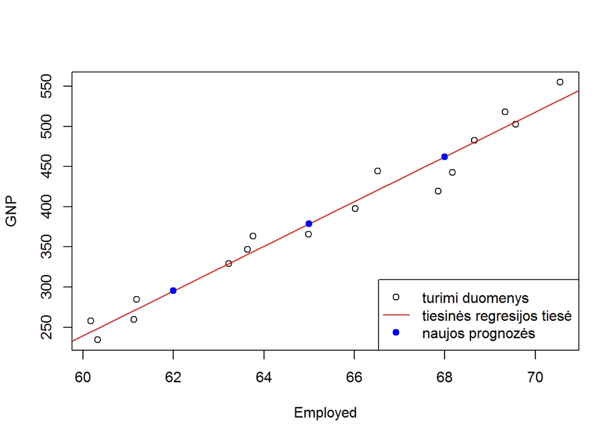

```r
plot(longley$Employed,longley$GNP, xlab="Employed", ylab="GNP")
abline(fit, col="red") #tiesė
points(newx, newy, col="blue", pch=19) # prognozės taškai

legend("bottomright", c("turimi duomenys","tiesinės regresijos tiesė", "naujos prognozės"), lty=c(0,1,0), pch=c(1, -1, 19), col = c("black","red", "blue"))
```

Šaltinis: http://www.algorithmist.ru/2011/04/linear-regression-with-examples-in-r.html?m=1